# data-viz slides

### Data Visualization With Pandas, Matplotlib, & Seaborn

The major chart types used in graphing data with Python.

- **Matplotlib**: The major library that others are built off of
- **Pandas**: Has built in matplotlib functions that allow you to graph based off of a dataframe
- **Seaborn**: User-friendly version of matplotlib, has a number of custom chart types that are very handy.

A really important detail is getting the correct dataframe for each graph!

```python
# load in the dataset
import pandas as pd
import numpy as np
import matplotlib.pyplot as plt
df = pd.read_csv('../data/titanic.csv')
```

```python
df.head()
```

|  | PassengerId | Survived | Pclass | Name | Sex | Age | SibSp | Parch | Ticket | Fare | Cabin | Embarked |
| --- | --- | --- | --- | --- | --- | --- | --- | --- | --- | --- | --- | --- |
| 0 | 1 | 0 | 3 | Braund, Mr. Owen Harris | male | 22.0 | 1 | 0 | A/5 21171 | 7.2500 | NaN | S |
| 1 | 2 | 1 | 1 | Cumings, Mrs. John Bradley (Florence Briggs Th... | female | 38.0 | 1 | 0 | PC 17599 | 71.2833 | C85 | C |
| 2 | 3 | 1 | 3 | Heikkinen, Miss. Laina | female | 26.0 | 0 | 0 | STON/O2. 3101282 | 7.9250 | NaN | S |
| 3 | 4 | 1 | 1 | Futrelle, Mrs. Jacques Heath (Lily May Peel) | female | 35.0 | 1 | 0 | 113803 | 53.1000 | C123 | S |
| 4 | 5 | 0 | 3 | Allen, Mr. William Henry | male | 35.0 | 0 | 0 | 373450 | 8.0500 | NaN | S |

```python
# we can take this dataframe view
df.Sex.value_counts()
```

```
male      577
female    314
Name: Sex, dtype: int64
```

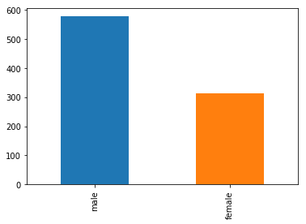

```python
# and turn it into this:
df.Sex.value_counts().plot(kind='bar')
```

### Categorical Data

- has the generic form:
  - category value -- numeric value
  - charts that can be created:
  - bar
  - barh
  - boxplot
  - pie

```python
# need to have information situation correctly
df['Embarked'].head(10)
```

```
0    S
1    C
2    S
3    S
4    S
5    Q
6    S
7    S
8    S
9    C
Name: Embarked, dtype: object
```

```python
# the following will not chart well
df['Embarked'].plot(kind='bar')
```

[output not shown]

```python
# let's take a look at another example
df.groupby('Sex')['Survived'].mean()
```

```
Sex
female    0.742038
male      0.188908
Name: Survived, dtype: float64
```

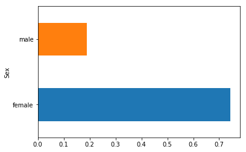

```python
# could chart it in the following way
df.groupby('Sex')['Survived'].mean().plot(kind='barh')
```

### Group Activity: Try and Create the Following Chart

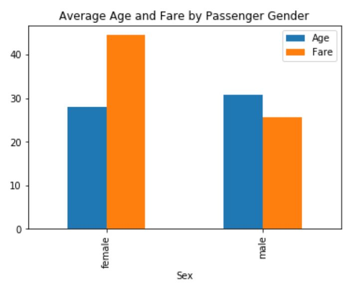

```python
from IPython.display import Image
Image(filename='plot.jpg')
```

```python
# correct code would look like this
df.groupby('Sex')[['Age', 'Fare']].mean().plot(kind='bar')
```

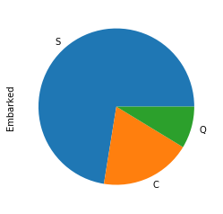

```python
# pie chart
df['Embarked'].value_counts().plot(kind='pie')
```

### Quantitative Data

- Either charting a single numeric variable, or numeric variables against one another
  - Major chart types:
  - histogram
  - scatter plot
  - kde
  - hexbin

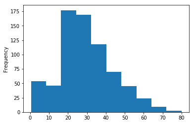

```python
# histogram
df['Age'].plot(kind='Hist')
```

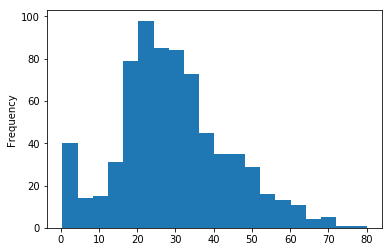

```python
# a few helpful options
df['Age'].plot(kind='Hist', bins=20)
```

```
array([[<matplotlib.axes._subplots.AxesSubplot object at 0x000001E5F5D2C6D8>,
      dtype=object)
```

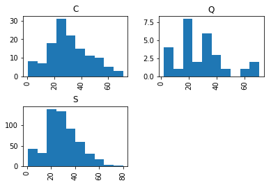

```python
# can also plot a histogram across an entire dataframe, and specify options
df.hist(column='Age', by='Embarked')
```

```
array([<matplotlib.axes._subplots.AxesSubplot object at 0x000001E5F553AFD0>,
      dtype=object)
```

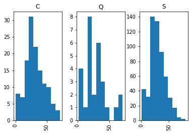

```python
# can specify the layout of columns and rows
df.hist(column='Age', by='Embarked', layout=(1, 3))
```

```
array([<matplotlib.axes._subplots.AxesSubplot object at 0x000001E5F6EE2160>,
      dtype=object)
```

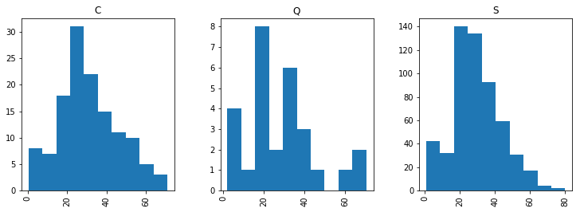

```python
# and the figure size
df.hist(column='Age', by='Embarked', layout=(1, 3), figsize=(12, 4))
```

```
array([<matplotlib.axes._subplots.AxesSubplot object at 0x000001E5F6EED470>,
      dtype=object)
```

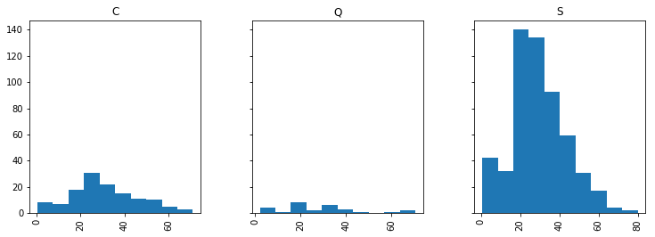

```python
# you can also force subplots to share an x and y axis
df.hist(column='Age', by='Embarked', layout=(1, 3), figsize=(12, 4), sharey=True)
```

## A Few More Helpful Charts......

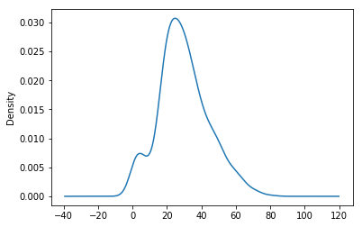

```python
# like a histogram, only its graphed based on density estimates
df['Age'].plot(kind='kde')
```

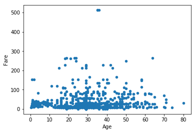

```python
# scatter plots have a unique syntax
df.plot('Age', 'Fare', kind='scatter')
```

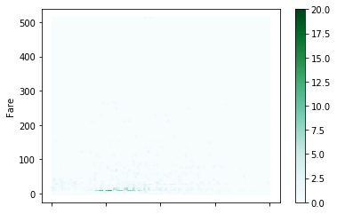

```python
df.plot('Age', 'Fare', kind='hexbin')
```

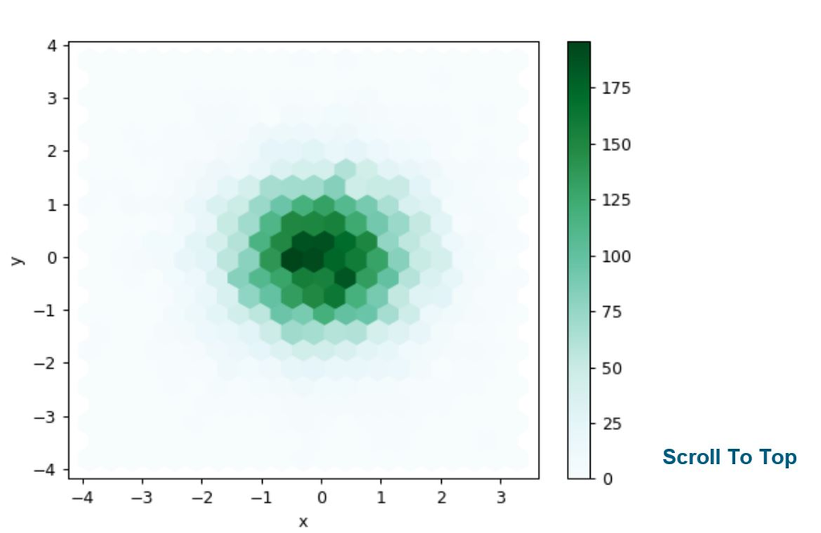

```python
Image(filename='plot2.jpg')
```

### A Few More Helpful Charting Tips:

- Creating Subplots for charts that pandas doesn't naturally use them for
- Doing overlays

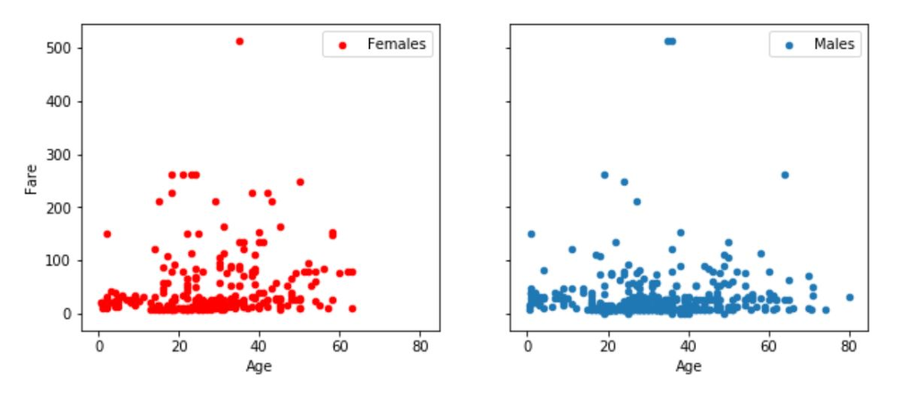

```python
Image(filename='plot3.jpg')
```

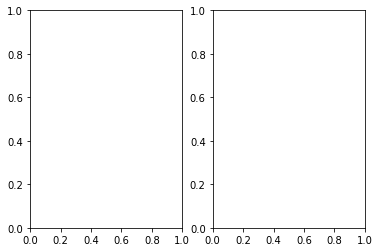

```python
fig, ax = plt.subplots(1, 2)
```

```python
ax
```

```
array([<matplotlib.axes._subplots.AxesSubplot object at 0x000001E5F7D28BE0>,
      dtype=object)
```

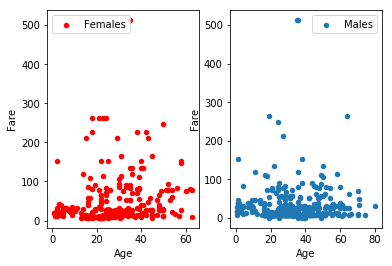

```python
# create a scatter plot
fig, ax = plt.subplots(1, 2)
df[df.Sex == 'female'].plot('Age', 'Fare', kind='Scatter', ax=ax[0], color='red', label='Females')
df[df.Sex == 'male'].plot('Age', 'Fare', kind='Scatter', ax=ax[1], label='Males')
```

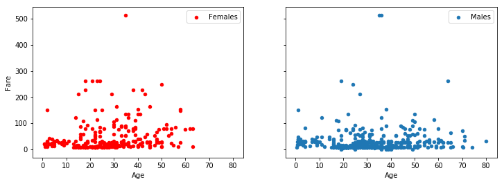

```python
# you can use the subplots command to set parameters for all charts
fig, ax = plt.subplots(1, 2, sharex=True, sharey=True, figsize=(12, 4))
df[df.Sex == 'female'].plot('Age', 'Fare', kind='Scatter', ax=ax[0], color='red', label='Females')
df[df.Sex == 'male'].plot('Age', 'Fare', kind='Scatter', ax=ax[1], label='Males')
```

### A Quick Word About Subplots

```
array([[<matplotlib.axes._subplots.AxesSubplot object at 0x000001E5F8F8C4A8>,
      dtype=object)
```

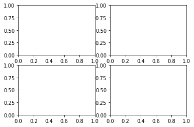

```python
# take a look at the following 2x2 series of subplots
fig, ax = plt.subplots(2, 2)
ax
```

```python
# this only grabs the axes in the first row!
ax[0]
```

```
array([<matplotlib.axes._subplots.AxesSubplot object at 0x000001E5F8F8C4A8>,
      dtype=object)
```

```python
# this grabs the the first axis in the first row
ax[0][0]
```

```python
# this grabs the second axis in the second row
ax[1][1]
```

### Overlays

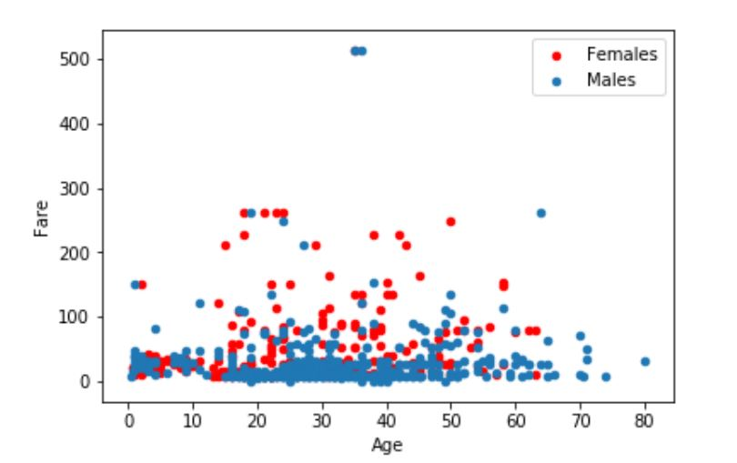

```python
Image(filename='plot4.jpg')
```

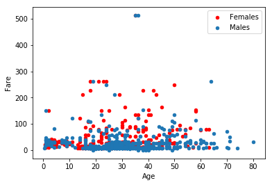

```python
ax = df[df.Sex == 'female'].plot('Age', 'Fare', kind='Scatter', color='red', label='Females')
df[df.Sex == 'male'].plot('Age', 'Fare', kind='Scatter', ax=ax, label='Males')
```

### Seaborn

```python
# import seaborn here
import seaborn as sns
```

### Primary Seaborn Chart Types:

- catplot
- relplot
- lmplot/regplot
- distplot/jointplot
- pairplot

### Categorical Data

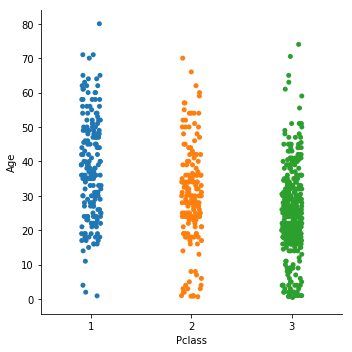

```python
# basic syntax for Seaborn - must specify x and y variables, as well as data source
sns.catplot(x='Pclass', y='Age', data=df)
```

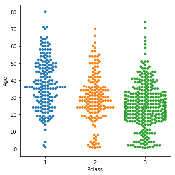

```python
# if you want to switch chart type, just use the 'kind' argument
sns.catplot(x='Pclass', y='Age', kind='swarm', data=df)
```

### Group Activity:

- Take 5 minutes to explore the types of charts returned by the following variants of the catplot:
  - swarm
  - strip
  - box
  - boxen
  - violin
  - point
  - bar
  - count

### Other Useful Arguments in Seaborn:

- hue
- col/row

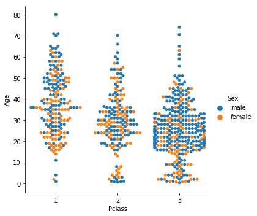

```python
# let's take a look at the same graph, but using hue to distinguish male from female
sns.catplot(x='Pclass', y='Age', kind='swarm', hue='Sex', data=df)
```

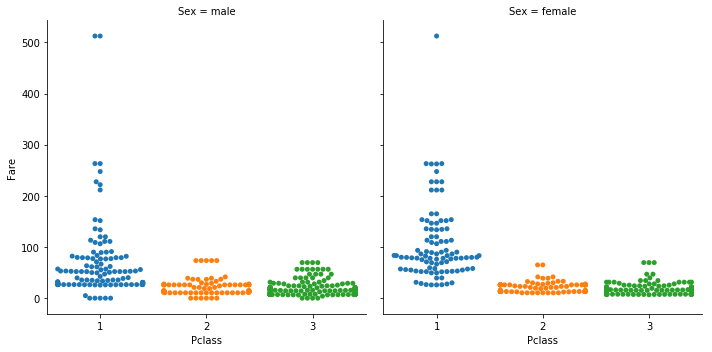

```python
# you can get a similar effect, but using each value as a separate column
sns.catplot(x='Pclass', y='Fare', kind='swarm', col='Sex', data=df)
```

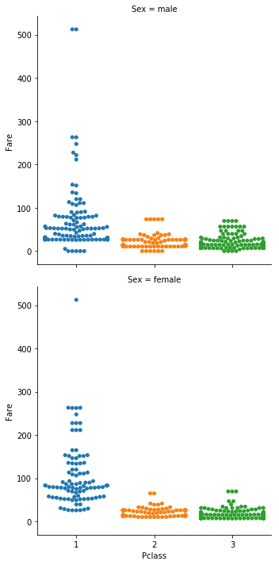

```python
# or as a row
sns.catplot(x='Pclass', y='Fare', kind='swarm', row='Sex', data=df)
```

### Group Activity

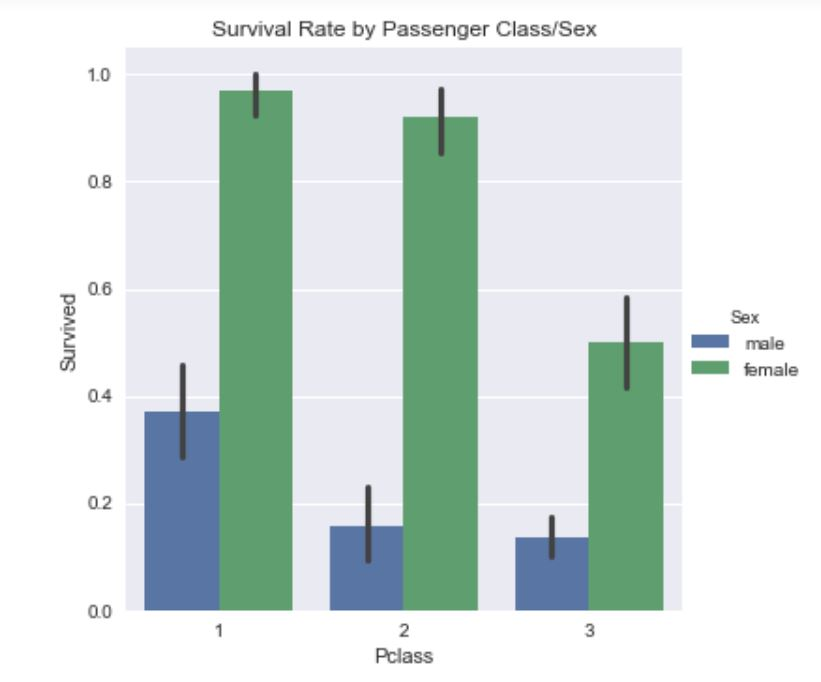

```python
Image(filename='plot5.jpg')
```

```python
# correct code would look like this
sns.catplot(x='Pclass', y='Survived', kind='bar', hue='Sex', data=df)
plt.title("Survival Rate by Passenger Class/Sex")
```

### Quantitative Data

- lmplots
- distribution/joint plots
- heatmaps/pairplots

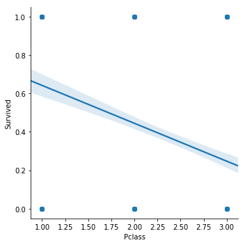

```python
# this draws a line of best fit through the data
sns.lmplot(x='Pclass', y='Survived', data=df)
```

### Everything regarding hue, col/row applies to the lmplot as well!

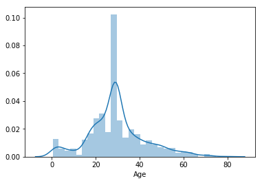

```python
# a better looking histogram
df['Age'] = df['Age'].fillna(29)
sns.distplot(df.Age)
```

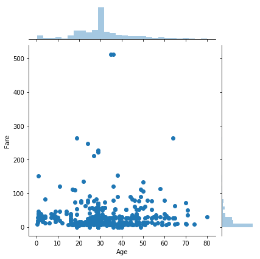

```python
# and if you want to get fancier.....
sns.jointplot(x='Age', y='Fare', data=df[df.Sex == 'male'])
```

### Hue and Col/Row do NOT work on distplots.

- However, you can use subplots, and the ax argument to create overlays
- Overlays using the ax argument will not work on jointplots

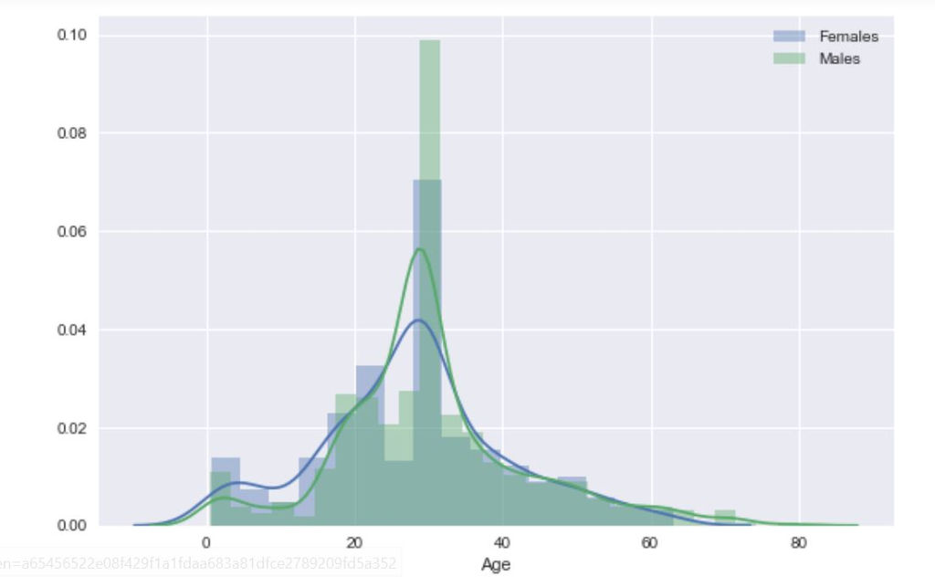

```python
Image(filename='plot6.jpg')
```

```python
# this code would give you the previous plot
ax = sns.distplot(df[df.Sex == 'female']['Age'], label='Females')
sns.distplot(df[df.Sex == 'male']['Age'], label='Males', ax=ax)
plt.legend(loc='best')
```

### Specialty Plots

- pairplots
- heatmaps

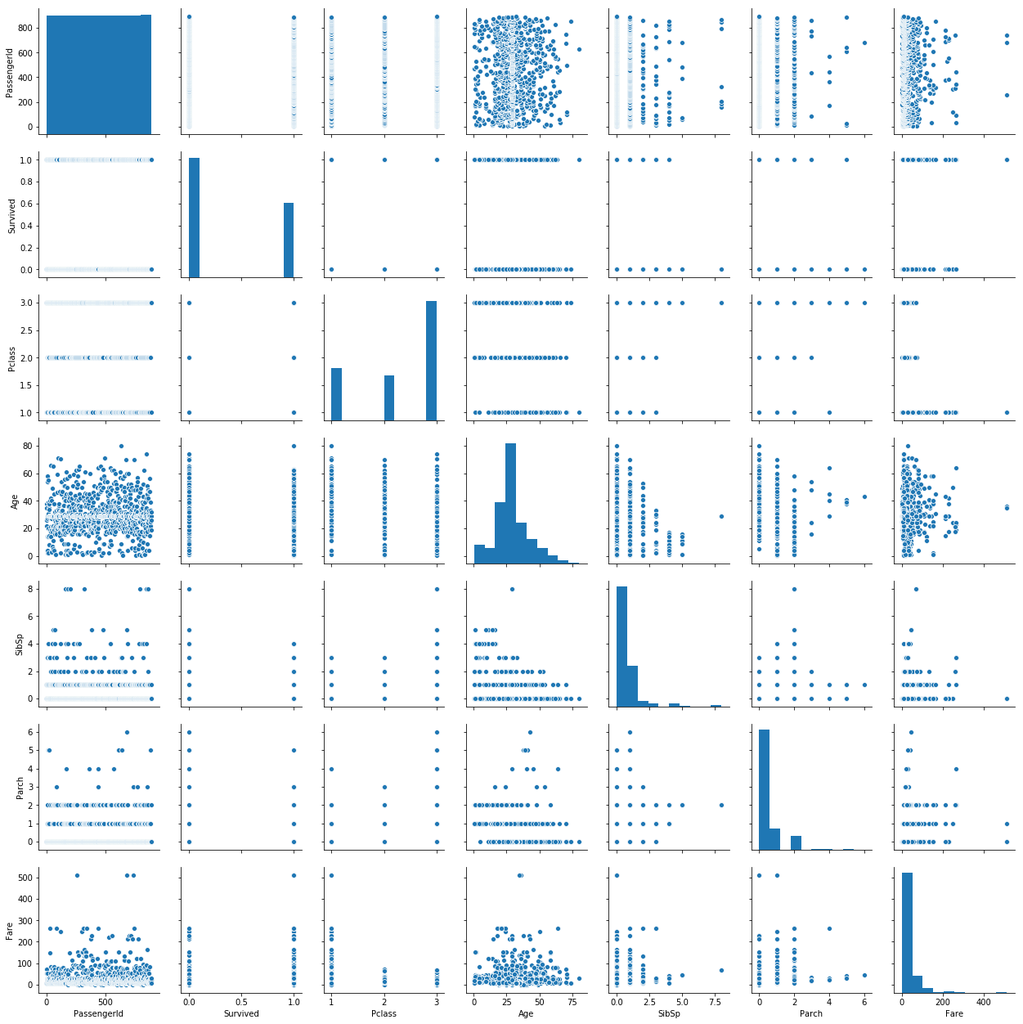

```python
# this pulls scatter plots, histograms of every quantitative variable in your dataset
sns.pairplot(df)
```

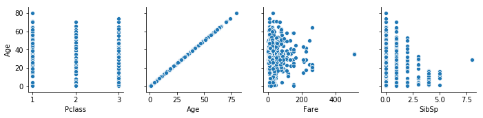

```python
# you can specify x and y variables
sns.pairplot(df, x_vars=['Pclass', 'Age', 'Fare', 'SibSp'], y_vars=['Age'])
```

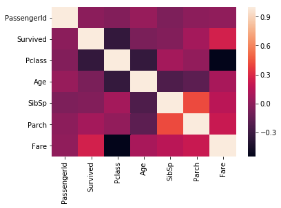

```python
# and finally......the heatmap
sns.heatmap(df.corr())
```